# Pertemuan 67

Reynd Hamonangan Pasaribu

2023-10-16

# Library

```r
library("forecast")
```

```r
library("graphics")
library("TTR")
library("TSA")
library(dplyr)
library(forecast)
library(lmtest)
library(orcutt)
library(HoRM)
library(corrplot)
library(dLagM)
library(dynlm)
library(MLmetrics)
library(ggplot2)
library(tsibble)
library(tseries)
library(MASS)
library(aTSA)
```

# Input Data

```r
datal <- rio::import("https://raw.githubusercontent.com/reyndpasaribu/MPDW/main/DATA/datal.csv")
datal
```

```
##     Periode  Suhu
## 1         1 26.26
## 2         2 26.89
## 3         3 26.81
## 4         4 27.17
## 5         5 27.08
## 6         6 26.30
## 7         7 26.05
## 8         8 26.11
## 9         9 26.45
## 10       10 26.12
## 11       11 26.09
## 12       12 25.41
## 13       13 25.55
## 14       14 25.91
```

[output cut: 130 more lines]

### Ubah Menjadi Data Time Series

```r
datal.ts <- ts(datal$Suhu)
```

### Membagi data menjadi data latih (80%) dan data uji (20%) dan jadikan time series

```r
dt.latih <- datal[1:115,2]
dt.uji <- datal[116:144,2]
dt.latih.ts <- ts(dt.latih, frequency = 12)
dt.uji.ts <- ts(dt.uji, frequency = 12)
```

# Eksplorasi data

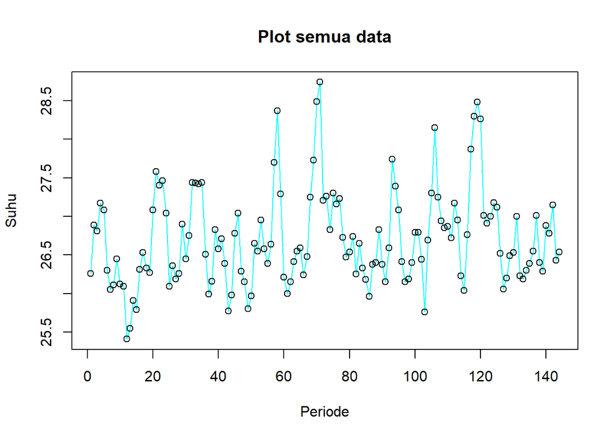

```r
# Semua Data
ts.plot(datal.ts, col="cyan",main="Plot semua data", type="o",xlab="Periode",ylab="Suhu")
points(datal.ts)
```

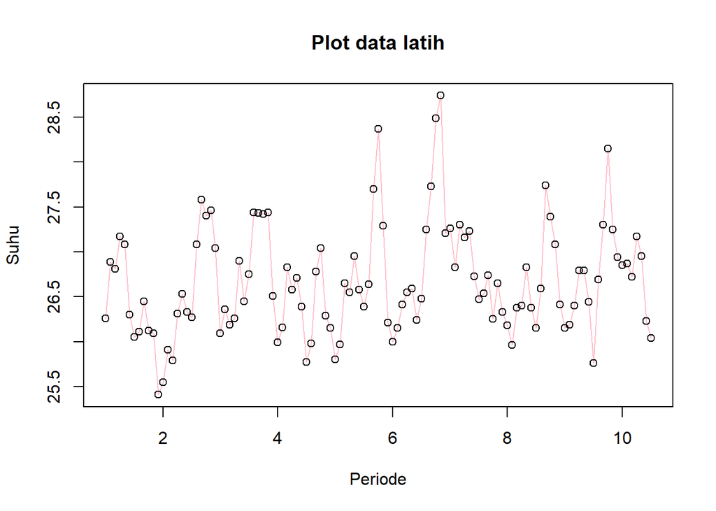

```r
# Data Train
ts.plot(dt.latih.ts, col="pink",main="Plot data latih", type="o",xlab="Periode",ylab="Suhu")
points(dt.latih.ts)
```

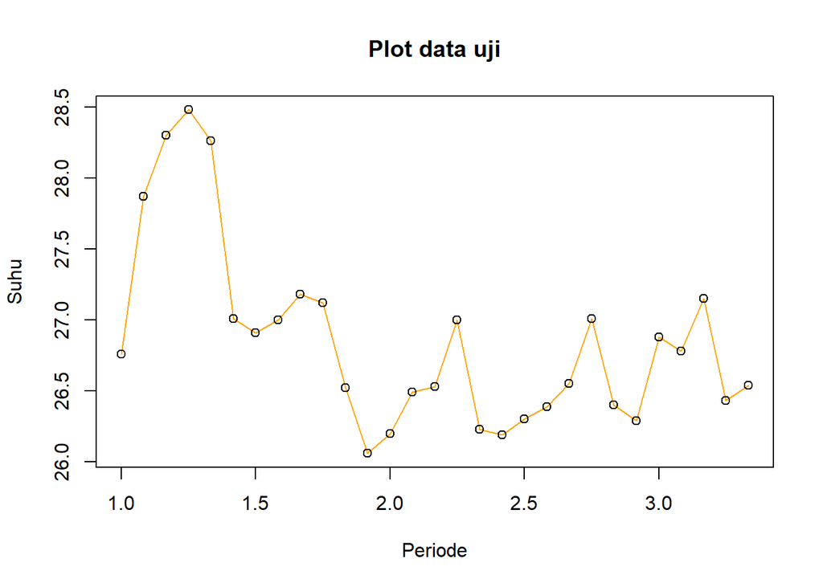

```r
# Data Test
ts.plot(dt.uji.ts, col="orange",main="Plot data uji", type="o",xlab="Periode",ylab="Suhu")
points(dt.uji.ts)
```

Dapat dilihat bahwwa data deret waktu pada suhu Lampung membentuk pola konstan tanpa trend

# Mengecek Kestasioneran Data

### Plot acf

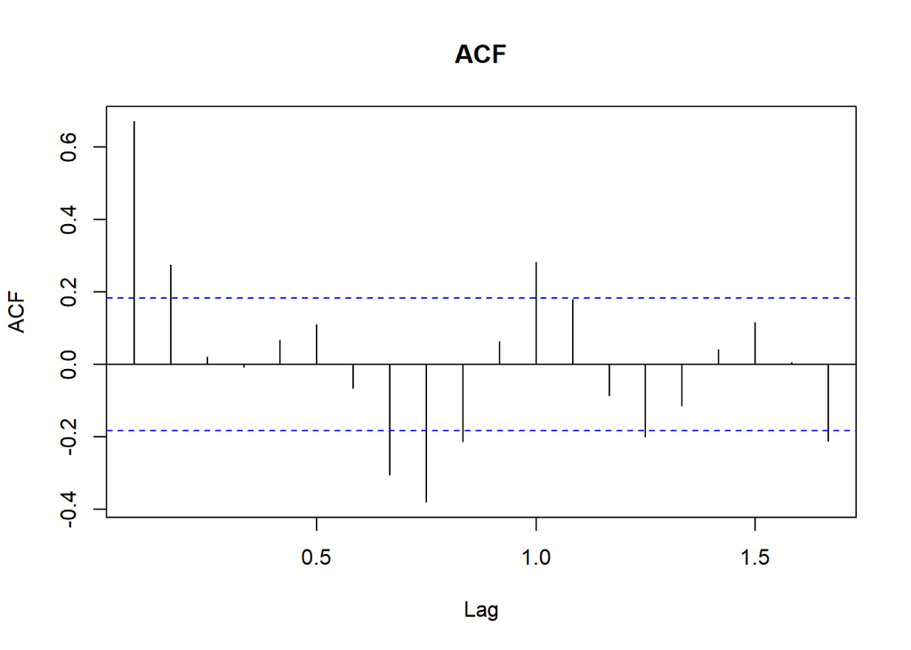

```r
acf(dt.latih.ts, main="ACF", lag.max=20)
```

Berdasarkan plot ACF, terlihat bahwa plot ACF pada data tersebut cenderung *tails off* dan membentuk gelombang sinus. menandakan bahwa data tersebut stasioner dalam rataan

### Uji ADF

```r
tseries::adf.test(dt.latih.ts)
```

```
##
##  Augmented Dickey-Fuller Test
##
## data:  dt.latih.ts
## Dickey-Fuller = -3.6563, Lag order = 4, p-value = 0.03129
## alternative hypothesis: stationary
```

$H_0$ : Data tidak stasioner dalam rataan $H_1$ : Data stasioner dalam rataan

Berdasarkan uji ADF tersebut, didapat *p-value* sebesar 0.03129 yang lebih kecil dari taraf nyata 5% sehingga tolak $H_0$ dan menandakan bahwa data stasioner dalam rataan. Hal ini sesuai dengan hasil eksplorasi menggunakan plot time series dan plot ACF.

### Plot Box-Cox

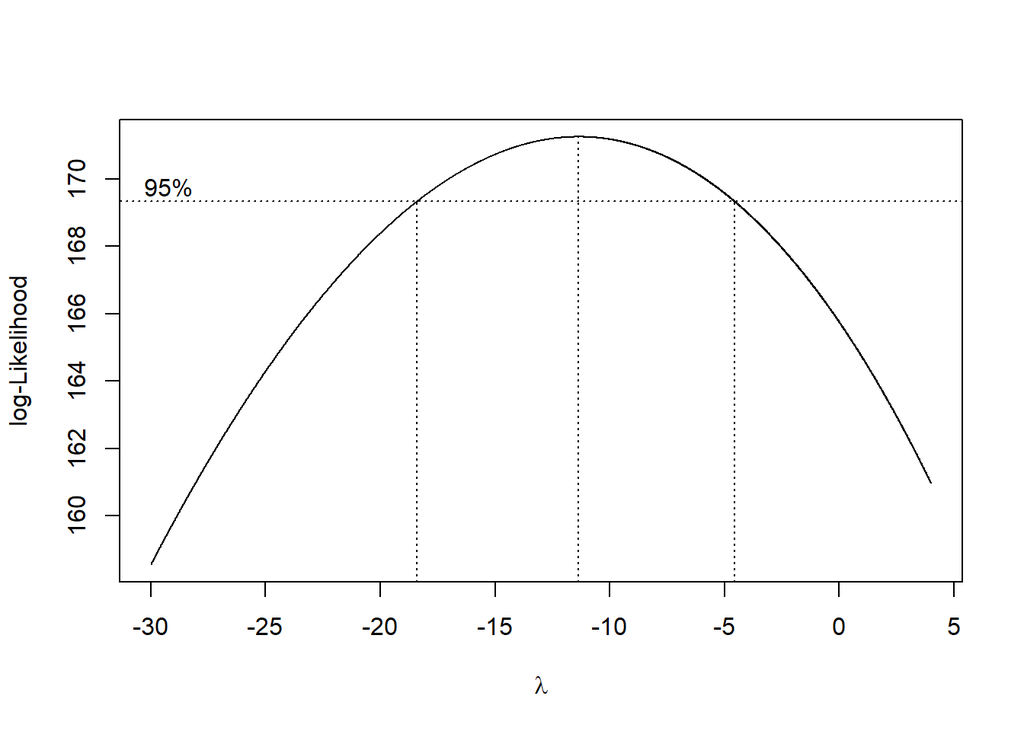

```r
index <- seq(1:115)
bc = boxcox(dt.latih.ts~index, lambda = seq(-30,4,by=0.01))
```

```r
#Nilai Rounded Lambda
lambda <- bc$x[which.max(bc$y)]
lambda
```

```
## [1] -11.36
```

```r
#SK
bc$x[bc$y > max(bc$y) - 1/2 * qchisq(.95,1)]
```

```
##    [1] -18.41 -18.40 -18.39 -18.38 -18.37 -18.36 -18.35 -18.34 -18.33 -18.32
##   [11] -18.31 -18.30 -18.29 -18.28 -18.27 -18.26 -18.25 -18.24 -18.23 -18.22
##   [21] -18.21 -18.20 -18.19 -18.18 -18.17 -18.16 -18.15 -18.14 -18.13 -18.12
##   [31] -18.11 -18.10 -18.09 -18.08 -18.07 -18.06 -18.05 -18.04 -18.03 -18.02
##   [41] -18.01 -18.00 -17.99 -17.98 -17.97 -17.96 -17.95 -17.94 -17.93 -17.92
##   [51] -17.91 -17.90 -17.89 -17.88 -17.87 -17.86 -17.85 -17.84 -17.83 -17.82
##   [61] -17.81 -17.80 -17.79 -17.78 -17.77 -17.76 -17.75 -17.74 -17.73 -17.72
##   [71] -17.71 -17.70 -17.69 -17.68 -17.67 -17.66 -17.65 -17.64 -17.63 -17.62
##   [81] -17.61 -17.60 -17.59 -17.58 -17.57 -17.56 -17.55 -17.54 -17.53 -17.52
##   [91] -17.51 -17.50 -17.49 -17.48 -17.47 -17.46 -17.45 -17.44 -17.43 -17.42
##  [101] -17.41 -17.40 -17.39 -17.38 -17.37 -17.36 -17.35 -17.34 -17.33 -17.32
##  [111] -17.31 -17.30 -17.29 -17.28 -17.27 -17.26 -17.25 -17.24 -17.23 -17.22
##  [121] -17.21 -17.20 -17.19 -17.18 -17.17 -17.16 -17.15 -17.14 -17.13 -17.12
##  [131] -17.11 -17.10 -17.09 -17.08 -17.07 -17.06 -17.05 -17.04 -17.03 -17.02
##  [141] -17.01 -17.00 -16.99 -16.98 -16.97 -16.96 -16.95 -16.94 -16.93 -16.92
```

[output cut: 124 more lines]

```r
tail(bc$x[bc$y > max(bc$y) - 1/2 * qchisq(.95,1)])
```

```
## [1] -4.62 -4.61 -4.60 -4.59 -4.58 -4.57
```

Gambar di atas menunjukkan nilai *rounded value* ($\lambda$) optimum sebesar **-11.36** dan pada selang kepercayaan 95% nilai memiliki batas bawah **-18.41** dan batas atas **-4.57**. Selang tersebut tidak memuat nilai satu sehingga dapat dikatakan bahwa data bangkitan tidak stasioner dalam ragam.